# a workflow for slides and papers

sebastian barfort  
NUMEDIG, april 2014

## Writing academic papers is a pain

- not only do you need a good idea
- you also need to turn that idea into a nice looking product
- it's a bit like sausage making in the sense that little attention is paid to how slides and papers are made
- my focus today is this process
  - most of you probably use either MS Word or LaTeX?
  - I'll try to make the case for a more stripped down text file approach

## What do we want?

- academic papers
- nice looking slides to sell our ideas

## How do we want them?

- today: primarily pdf
- in the future (but the future is now): also html

### The perfect workflow

**input**

- text
- equations
- plots
- tables
- citations

**output**

- pdf or html
- because of some unexplainable facts about the world: docx
- we do not want to worry about citations, equations, etc.
- we *do not* want to do any post-processing (this is tedius and not reproducible)

If only there were some program that could do all these things…

## Enter: Pandoc!

### Pandoc

- written by John Macfarlane (philosophy prof at UC Berkeley, *hobby* programmer)
- Pandoc is your swiss-army knife for document conversion
- Among a huge set of inputs, Pandoc accepts LaTeX

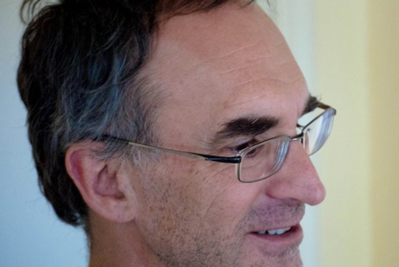

### Article

1. `.tex` to `.html`

   pandoc -s paper.tex -o paper_tex.html
2. `.tex` to `.docx`

   pandoc -s paper.tex -o paper_tex.docx

### Slides

1. `.tex` to beamer slides

   pandoc -t beamer slides.tex -o slides_tex.pdf
2. `.tex` to `.html` slides

   pandoc -s –mathml -i -t dzslides slides.tex -o slides_tex.html
3. using the slidy framework

   pandoc -s –webtex -i -t slidy slides.tex -o slides_tex.html

## If you absolutely love LaTeX, stop here...

## I think we can do better

- I can write an entire slideshow in the time it takes you to type `\documentclass{beamer}`, `\title{}`, etc
- I never remember the commands
- I never understand the error messsages
- … and I think beamer slides are ugly

If only there were ever some simpler program that could give us the same funtionality…

## Enter Markdown!

## Markdown philosophy

> - writing should not be an alienating experience trapped in WYSIWYG editors
> - a file should be readable intuitively and not be buried in markup
> - markdown *is* a markup language, but one meant to be read by humans rather than machines
- markdown was created for the web (you know it if you use Github, Stackoverflow, etc.)

## Example

Suppose we want to create a nested list

- fruits
  - apples
    - macintosh
    - red delicious
  - pears
  - peaches
- vegetables
  - broccoli
  - chard

## Latex

```
\begin{itemize}
\item fruits
    \begin{itemize}
    \item apples
        \begin{itemize}
        \item macintosh
        \item red delicious
        \end{itemize}
    \item pears
    \item peaches
    \end{itemize}
\item vegetables
    \begin{itemize}
    \item brocolli
    \item chard
    \end{itemize}
\end{itemize}
```

## HTML

```
<ul>
    <li>fruits
    <ul>
        <li>apples
        <ul>
            <li>macintosh</li>
            <li>red delicious</li>
        </ul></li>
        <li>pears</li>
        <li>peaches</li>
    </ul></li>
    <li>vegetables
    <ul>
        <li>brocolli</li>
        <li>chard</li>
    </ul></li>
</ul>
```

## Markdown

```
* fruits
    - apples
        - macintosh
        - red delicious
    - pears
    - peaches
* vegetables
    - broccoli
    - chard
```

### Article

1. `.md` to `.html`

   pandoc -s paper.md -o paper_md.html
2. `.md` to `.pdf`

   pandoc -s paper.md -o paper_md.pdf

### Slides

1. `.md` to beamer slides

   pandoc -t beamer slides.md -o slides_md.pdf
2. using the slidy `.html` framework

   pandoc -s –webtex -i -t slidy slides.md -o slides_md.html

## The general idea

- markdown is *extremely* easy to learn
- it is widely used, with almost endless possibilities
- so why not use it for academic papers?

[figure not shown]

## Some technical stuff…

- customize your stylesheet
  - latex template
  - install proper fonts (minion pro)
  - pandoc templates
- get help [here](http://kieranhealy.org/blog/archives/2014/01/23/plain-text/)
- my style files are on [github](https://github.com/sebastianbarfort/numedig/tree/master/2-workflow/templates)
- let's see an example of a real paper (which won't be online until there's a draft ready)

## More technical stuff

- html doesn't understand latex tables (and vice versa)
- so we need to be able to typeset
  - markdown tables
  - latex and html tables
- you can include raw html and latex code in your markdown file
- can your favorite stats program do that?

## Some can…

```r
library(stargazer)
linear.1 <- lm(rating ~ complaints + privileges + learning + raises + critical,
data=attitude)
linear.2 <- lm(rating ~ complaints + privileges + learning, data=attitude)
## create an indicator dependent variable, and run a probit model
attitude$high.rating <- (attitude$rating > 70)
probit.model <- glm(high.rating ~ learning + critical + advance, data=attitude,
family = binomial(link = "probit"))
```

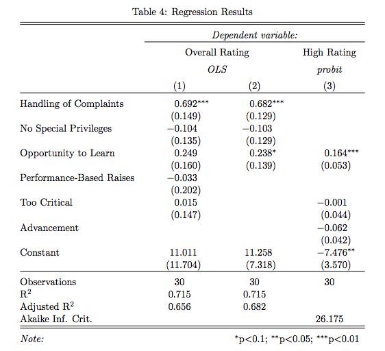

**Results**

|  | *Dependent variable:* |  |  |
| --- | --- | --- | --- |
|  | rating |  | high.rating |
|  | *OLS* |  | *probit* |
|  | (1) | (2) | (3) |
| complaints | 0.692*** | 0.682*** |  |
|  | (0.149) | (0.129) |  |
| privileges | -0.104 | -0.103 |  |
|  | (0.135) | (0.129) |  |
| learning | 0.249 | 0.238* | 0.164*** |
|  | (0.160) | (0.139) | (0.053) |
| raises | -0.033 |  |  |
|  | (0.202) |  |  |
| critical | 0.015 |  | -0.001 |
|  | (0.147) |  | (0.044) |
| advance |  |  | -0.062 |
|  |  |  | (0.042) |
| Constant | 11.010 | 11.260 | -7.476** |
|  | (11.700) | (7.318) | (3.570) |
| Observations | 30 | 30 | 30 |
| R<sup>2</sup> | 0.715 | 0.715 |  |
| Adjusted R<sup>2</sup> | 0.656 | 0.682 |  |
| Log Likelihood |  |  | -9.087 |
| Akaike Inf. Crit. |  |  | 26.180 |
| Residual Std. Error | 7.139 (df = 24) | 6.863 (df = 26) |  |
| F Statistic | 12.060*** (df = 5; 24) | 21.740*** (df = 3; 26) |  |
| *Note:* | *p<0.1; **p<0.05; ***p<0.01 |  |  |

- it would be even better to output markdown tables
- this is almost possible in `R` and is a project at GSOC 2014

```r
library(pander)
m <- mtcars[1:5, 1:3]
pandoc.table(m, style = "rmarkdown")
```

```
|         &nbsp;          |  mpg  |  cyl  |  disp  |
|:-----------------------:|:-----:|:-----:|:------:|
|      **Mazda RX4**      |  21   |   6   |  160   |
|    **Mazda RX4 Wag**    |  21   |   6   |  160   |
|     **Datsun 710**      | 22.8  |   4   |  108   |
|   **Hornet 4 Drive**    | 21.4  |   6   |  258   |
|  **Hornet Sportabout**  | 18.7  |   8   |  360   |
```

## output

|  | mpg | cyl | disp |
| --- | --- | --- | --- |
| **Mazda RX4** | 21 | 6 | 160 |
| **Mazda RX4 Wag** | 21 | 6 | 160 |
| **Datsun 710** | 22.8 | 4 | 108 |
| **Hornet 4 Drive** | 21.4 | 6 | 258 |
| **Hornet Sportabout** | 18.7 | 8 | 360 |

## Thank you

- materials are on [github](https://github.com/sebastianbarfort/numedig/tree/master/2-workflow)
- thanks to [Kearan Healy](http://kieranhealy.org/) for his templates